# Analysis of Diabetes Health Indicators / Dataset by Behavioral Risk Factor Surveillance System

January 2023

Juan José Tirado Pulido / Sheddad

- General questions
- Section 1
  - 1.1
  - 1.2
  - 1.3
    - Apartado a
    - Apartado b
    - Apartado c
- Sección 2
  - 2.1
    - Apartado a
    - Apartado b
    - Apartado c
    - Apartado d
  - 2.2
    - Apartado a
    - Apartado b
    - Apartado c
    - Apartado d
- Sección 3

# General questions

This questions were proposed in the website ([KAGGLE](https://www.kaggle.com/datasets/alexteboul/diabetes-health-indicators-dataset)))

- Can survey questions from the BRFSS provide accurate predictions of whether an individual has diabetes?
- What risk factors are most predictive of diabetes risk?
- Can we use a subset of the risk factors to accurately predict whether an individual has diabetes?
- Can we create a short form of questions from the BRFSS using feature selection to accurately predict if someone might have diabetes or is at high risk of diabetes?

# Section 1

## 1.1

Let’s explore the kind of files that will be imported and the relevant variables of study

```r
diabetes_dataset <- read.csv("dataset/diabetes_012_health_indicators_BRFSS2015.csv",
                             header=TRUE)
names(diabetes_dataset)
```

```
##  [1] "Diabetes_012"         "HighBP"               "HighChol"
##  [4] "CholCheck"            "BMI"                  "Smoker"
##  [7] "Stroke"               "HeartDiseaseorAttack" "PhysActivity"
## [10] "Fruits"               "Veggies"              "HvyAlcoholConsump"
## [13] "AnyHealthcare"        "NoDocbcCost"          "GenHlth"
## [16] "MentHlth"             "PhysHlth"             "DiffWalk"
## [19] "Sex"                  "Age"                  "Education"
## [22] "Income"
```

The variables are:

- Diabetes_012: 0 = no diabetes 1 = prediabetes 2 = diabetes
- HighBP: 0 = no high BP 1 = high BP
- HighChol: 0 = no high cholesterol 1 = high cholesterol
- CholCheck: 0 = no cholesterol check in 5 years 1 = yes cholesterol check in 5 years
- BMI: Body Mass Index
- Smoker: Have you smoked at least 100 cigarettes in your entire life? [Note: 5 packs = 100 cigarettes] 0 = no 1 = yes
- Stroke: You ever had a stroke. 0 = no 1 = yes
- HeartDiseaseorAttack: coronary heart disease (CHD) or myocardial infarction (MI) 0 = no 1 = yes
- PhysActivity: physical activity in past 30 days - not including job 0 = no 1 = yes
- Fruits: Consume Fruit 1 or more times per day 0 = no 1 = yes
- Veggies: Consume Vegetables 1 or more times per day 0 = no 1 = yes
- HvyAlcoholConsump: Heavy drinkers (adult men having more than 14 drinks per week and adult women having more than 7 drinks per week) 0 = no 1 = yes
- AnyHealthcare: Have any kind of health care coverage, including health insurance, prepaid plans such as HMO, etc. 0 = no 1 = yes
- NoDocbcCost: Was there a time in the past 12 months when you needed to see a doctor but could not because of cost? 0 = no 1 = yes
- GenHlth: Would you say that in general your health is: scale 1-5 1 = excellent 2 = very good 3 = good 4 = fair 5 = poor
- MentHlth: Now thinking about your mental health, which includes stress, depression, and problems with emotions, for how many days during the past 30 days was your mental health not good?
- PhysHlth: Now thinking about your physical health, which includes physical illness and injury, for how many days during the past 30 days was your physical health not good?
- DiffWalk: Do you have serious difficulty walking or climbing stairs? 0 = no 1 = yes
- Sex: 0 = female 1 = male
- Age: 13-level age category ([_AGEG5YR](https://www.icpsr.umich.edu/web/NAHDAP/studies/34085/datasets/0001/variables/EDUCA?archive=NAHDAP))) 1 = 18-24 9 = 60-64 13 = 80 or older
- Education: Education level ([EDUCA](https://www.icpsr.umich.edu/web/NAHDAP/studies/34085/datasets/0001/variables/EDUCA?archive=NAHDAP)) scale 1-6 1 = Never attended school or only kindergarten 2 = Grades 1 through 8
- Income: Income scale ([INCOME2](https://www.icpsr.umich.edu/web/RCMD/studies/34085/datasets/0001/variables/INCOME2?archive=RCMD)) scale 1-8, 1 = less than $10000, 5 = less than $35000, 8 = $75,000 or more

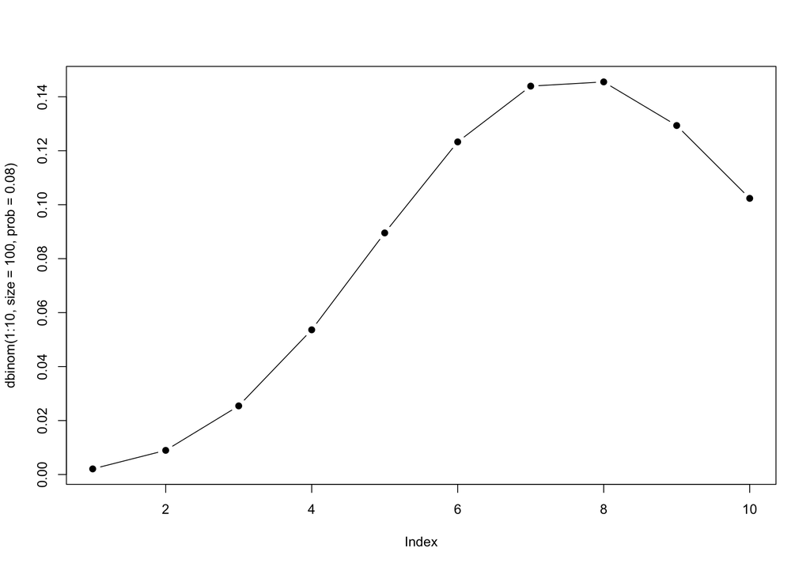

```r
#Diagrama de puntos las probabilidades de todos los valores hasta 10
plot(dbinom(1:10, size = 100, prob = .08), type = "b", pch = 19)
```

## 1.2

La distribución de Poisson expresa la probabilidad de que un cierto número de eventos sucedan en un intervalo de espacio o tiempo fijo, si dichos eventos ocurren con una media conocida y los eventos son independientes.

En promedio, se producen 9 incidentes al mes que derivan en quemaduras, intoxicaciones, etc. Por lo tanto lambda = 9.

```r
#Probabilidad de que, en un mes cualquiera, se produzcan 11 o más incidentes.
media_incidentes <- 9
numero_incidentes <- 10

ppois(numero_incidentes, media_incidentes, lower.tail = FALSE)
```

```
## [1] 0.2940117
```

La probabilidad de que haya 11 o más incidentes cuando la media es de 9 incidentes es 29.4%

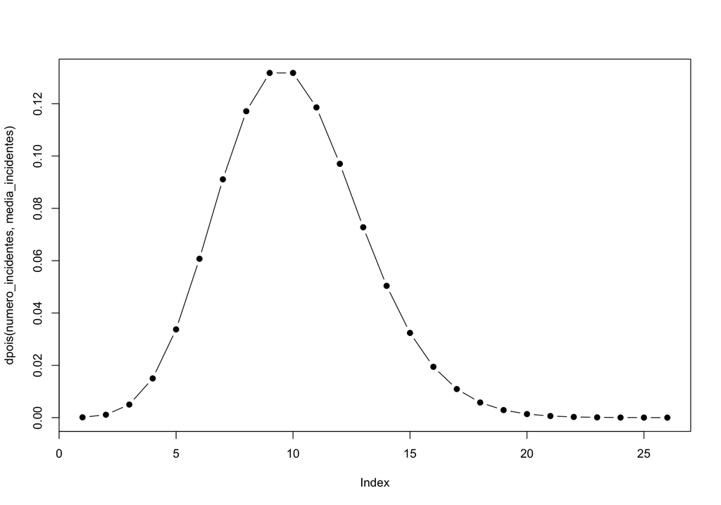

```r
#Se pide también explicar a qué tipo de distribución corresponde y la
#representación gráfica de la distribución teniendo en cuenta la media,
#para un número determinado de valores (por ejemplo, 25).

numero_incidentes <- 0:25
media_incidentes <- 9

plot(dpois(numero_incidentes, media_incidentes), type = "b", pch = 19)
```

## 1.3

Según los datos recogidos, un tratamiento abrasivo para el acné juvenil se realiza en diferentes fases según la reacción del paciente, teniendo una duración media de 25 días, y una desviación estándar de 5 días.

### Apartado a

```r
(pnorm(27, mean = 25, sd = 5) - pnorm(22, mean = 25, sd = 5)) * 100
```

```
## [1] 38.11686
```

Para calcular la probabilidad de que el tratamiento se realize entre 22 y 27 días, restamos P(X <= 27 días) a P(X <= 22 días). Y nos da 38.12%

### Apartado b

```r
dist_normal_acne <- rnorm(10000, mean = 25, sd = 5)
mean(dist_normal_acne)
```

```
## [1] 25.00492
```

### Apartado c

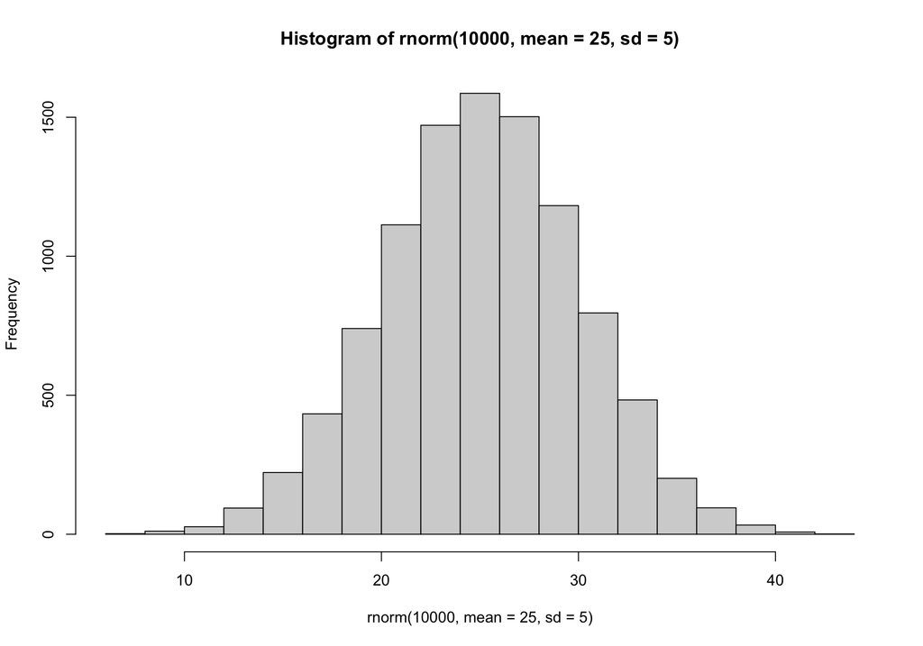

```r
hist(rnorm(10000, mean = 25, sd = 5))
```

Como podemos observar, se trata de una distribución normal. Si seguimos la regla 68-95-99.7 y siendo la media = 25 podemos observar que:

- Un 68% de los resultados están a una desviación estándar de la media.
- Un 95% de los resultados están a dos desviaciones estándar de la media.
- Un 99.7% de los resultados están a tres desviaciones estándar de la media.

# Sección 2

## 2.1

```r
library(MASS)
head(Aids2)
```

```
##   state sex  diag death status T.categ age
## 1   NSW   M 10905 11081      D      hs  35
## 2   NSW   M 11029 11096      D      hs  53
## 3   NSW   M  9551  9983      D      hs  42
## 4   NSW   M  9577  9654      D    haem  44
## 5   NSW   M 10015 10290      D      hs  39
## 6   NSW   M  9971 10344      D      hs  36
```

```r
str(Aids2)
```

```
## 'data.frame':    2843 obs. of  7 variables:
##  $ state  : Factor w/ 4 levels "NSW","Other",..: 1 1 1 1 1 1 1 1 1 1 ...
##  $ sex    : Factor w/ 2 levels "F","M": 2 2 2 2 2 2 2 2 2 2 ...
##  $ diag   : int  10905 11029 9551 9577 10015 9971 10746 10042 10464 10439 ...
##  $ death  : int  11081 11096 9983 9654 10290 10344 11135 11069 10956 10873 ...
##  $ status : Factor w/ 2 levels "A","D": 2 2 2 2 2 2 2 2 2 2 ...
##  $ T.categ: Factor w/ 8 levels "hs","hsid","id",..: 1 1 1 5 1 1 8 1 1 2 ...
##  $ age    : int  35 53 42 44 39 36 36 31 26 27 ...
```

Para poder hallar la correlación, las columnas que son factores deben ser pasadas a numeric.

### Apartado a

```r
#Eliminando NA's
Aids2 <- na.omit(Aids2)

Aids2_numeric <- Aids2
#Para poder hallar la correlación, tenemos que convertir en numéricos los datos que no lo son
Aids2_numeric$state <- as.numeric(Aids2_numeric$state)
Aids2_numeric$sex <- as.numeric(Aids2_numeric$sex)
Aids2_numeric$status <- as.numeric(Aids2_numeric$status)
Aids2_numeric$T.categ <- as.numeric(Aids2_numeric$T.categ)
```

### Apartado b

```r
#Funcion que devuelve un vector compuesto por el número de low outliers y el de
#high outliers
number_outliers_boxplot <- function(boxplot) {
  outliers <- boxplot$out
  upper_whisker <- boxplot$stats[5]
  num_low_outliers <- length(which(outliers < upper_whisker))
  num_high_outliers <- length(which(outliers > upper_whisker))

  return (c(num_low_outliers, num_high_outliers))
}
```

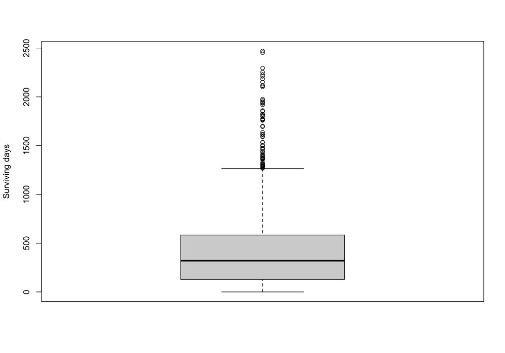

```r
survival_days <- Aids2$death - Aids2$diag
bp_survival_days <- boxplot(survival_days, ylab = "Surviving days")
```

```r
#Obteniendo los quartiles
q3 <- bp_survival_days$stats[4]
q1 <- bp_survival_days$stats[2]

q3
```

```
## [1] 583
```

```r
q1
```

```
## [1] 128
```

```r
# Obteniendo el número de high and low outliers
num_low_outliers <- number_outliers_boxplot(bp_survival_days)[1]
num_high_outliers <- number_outliers_boxplot(bp_survival_days)[2]

num_low_outliers
```

```
## [1] 0
```

```r
num_high_outliers
```

```
## [1] 79
```

Aquí podemos ver un diagrama de cajas para los días que el paciente ha vivido durante el estudio, cayendo un 50% de los valores entre 583 (Q3) y 128 días (Q1)

Como outliers tenemos:

- Lower outlier: no hay ya que no se puede vivir -554.5 días
- High outlier: hay 79 personas en el estudio que han vivido más de 1265.5 días

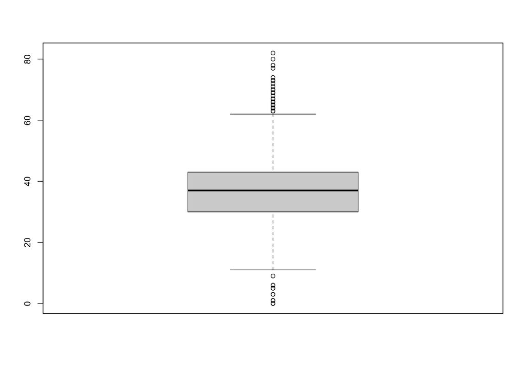

```r
bp_age <- boxplot(Aids2$age)
```

```r
#Obteniendo los quartiles
q3 <- bp_age$stats[4]
q1 <- bp_age$stats[2]

q3
```

```
## [1] 43
```

```r
q1
```

```
## [1] 30
```

```r
# Obteniendo el número de high and low outliers
num_low_outliers <- number_outliers_boxplot(bp_age)[1]
num_high_outliers <- number_outliers_boxplot(bp_age)[2]

num_low_outliers
```

```
## [1] 16
```

```r
num_high_outliers
```

```
## [1] 56
```

Un 50% de los pacientes se encuentran entre 43 (Q3) y 30 (Q1). Como outliers tenemos:

- Lower outlier: hay 16 pacientes con menos de 10.5 años.
- High outlier: hay 56 pacientes con más de 62.5 años.

### Apartado c

```r
#Correlación habiendo convertido las variables en numéricas
numeric_correlation <- cor(Aids2_numeric, method = 'pearson')
numeric_correlation
```

```
##               state          sex        diag       death       status
## state    1.00000000  0.011760002  0.06507146  0.06060914 -0.014042798
## sex      0.01176000  1.000000000  0.03970979  0.03116425  0.008852891
## diag     0.06507146  0.039709786  1.00000000  0.83115053 -0.546397703
## death    0.06060914  0.031164248  0.83115053  1.00000000 -0.642865551
## status  -0.01404280  0.008852891 -0.54639770 -0.64286555  1.000000000
## T.categ -0.03154348 -0.412248059 -0.03486147 -0.05586882  0.006223458
## age     -0.01741994 -0.014773832  0.02481272 -0.03955591  0.048717892
##              T.categ         age
## state   -0.031543476 -0.01741994
## sex     -0.412248059 -0.01477383
## diag    -0.034861474  0.02481272
## death   -0.055868820 -0.03955591
## status   0.006223458  0.04871789
## T.categ  1.000000000  0.04746117
## age      0.047461168  1.00000000
```

Representación visual de la correlación

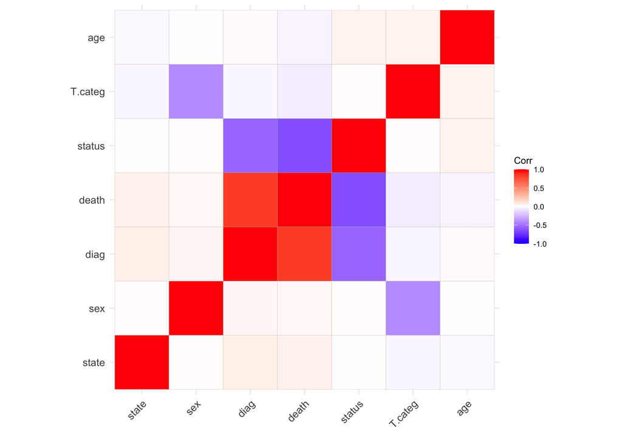

```r
library(ggcorrplot)

ggcorrplot(numeric_correlation)
```

### Apartado d

```r
lrm_diag_death <- lm(diag ~ death, data = Aids2)
summary(lrm_diag_death)
```

```
##
## Call:
## lm(formula = diag ~ death, data = Aids2)
##
## Residuals:
##      Min       1Q   Median       3Q      Max
## -1978.55  -178.61    59.34   253.45   490.45
##
## Coefficients:
##              Estimate Std. Error t value Pr(>|t|)
## (Intercept) 1.424e+03  1.152e+02   12.36   <2e-16 ***
## death       8.335e-01  1.046e-02   79.67   <2e-16 ***
## ---
## Signif. codes:  0 '***' 0.001 '**' 0.01 '*' 0.05 '.' 0.1 ' ' 1
##
## Residual standard error: 348.8 on 2841 degrees of freedom
## Multiple R-squared:  0.6908, Adjusted R-squared:  0.6907
## F-statistic:  6348 on 1 and 2841 DF,  p-value: < 2.2e-16
```

Las variables fecha de diagnóstico y fecha de muerte / final de observación tienen una fuerte correlación positiva ya que R^2 es 0.6907 y es estadísticamente significativo ya que el p-value es menor que 2.2e-16.

```r
lrm_sex_death <- lm(death ~ status, data = Aids2)
summary(lrm_sex_death)
```

```
##
## Call:
## lm(formula = death ~ status, data = Aids2)
##
## Residuals:
##      Min       1Q   Median       3Q      Max
## -2206.18    -7.62     0.94   281.82   828.82
##
## Coefficients:
##             Estimate Std. Error t value Pr(>|t|)
## (Intercept) 11503.06      14.57  789.76   <2e-16 ***
## statusD      -827.87      18.51  -44.73   <2e-16 ***
## ---
## Signif. codes:  0 '***' 0.001 '**' 0.01 '*' 0.05 '.' 0.1 ' ' 1
##
## Residual standard error: 479.1 on 2841 degrees of freedom
## Multiple R-squared:  0.4133, Adjusted R-squared:  0.4131
## F-statistic:  2001 on 1 and 2841 DF,  p-value: < 2.2e-16
```

## 2.2

### Apartado a

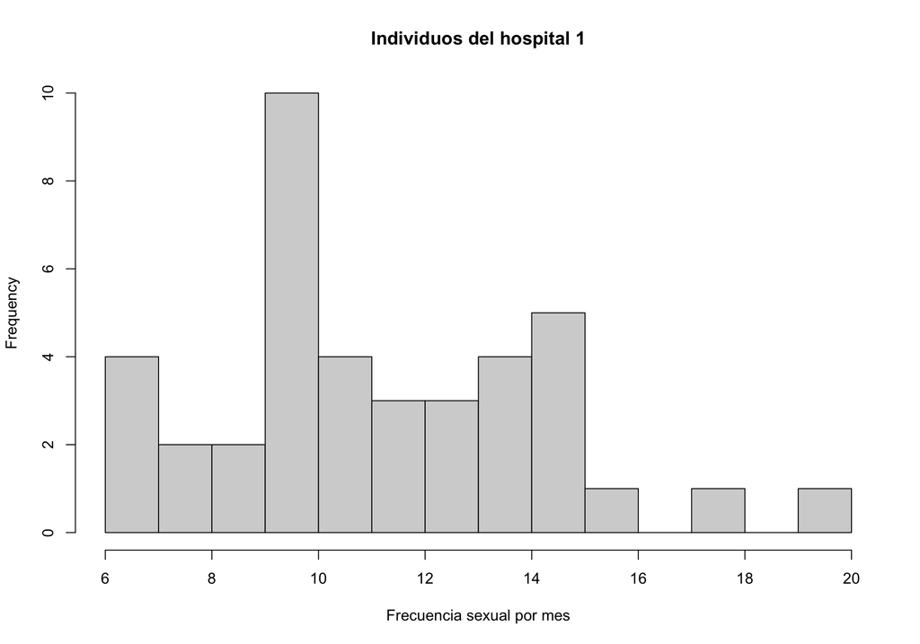

```r
#Frecuencia sexual de individuos en tres hospitales
sex_hospital_1 <- c(11, 14, 7, 15, 11, 13, 11, 16, 10, 15, 18, 12, 9, 9, 10, 10, 15, 10, 14, 10, 10, 12, 14, 12, 15, 7, 13, 6, 10,  15, 20, 10, 13, 10, 6, 14, 8, 10, 8, 11)
factor_hospital_1 <- as.factor('Hospital 1')

sex_hospital_2 <- c(13, 10, 12, 7, 5, 10, 10, 16, 9, 7, 7, 2, 6, 9, 9, 8, 8, 10, 3, 6, 5, 2, 9, 3, 4, 5, 10, 8, 5, 9, 10, 8, 13, 10, 0, 2, 1, 1, 0, 4)
factor_hospital_2 <- as.factor('Hospital 2')

sex_hospital_3 <- c(6, 7, 3, 5, 9, 6, 1, 6, 0, 2, 5, 6, 11, 6, 7, 0, 5, 7, 5, 4, 7, 4, 2, 8, 9, 6, 1, 4, 7, 7, 8, 9, 7, 5, 1, 6, 9, 4, 7, 6)
factor_hospital_3 <- as.factor('Hospital 3')

#Veamos los histogramas para ver si siguen una distribución normal
hist(sex_hospital_1,
     breaks = 10,
     main = 'Individuos del hospital 1',
     xlab = 'Frecuencia sexual por mes')
```

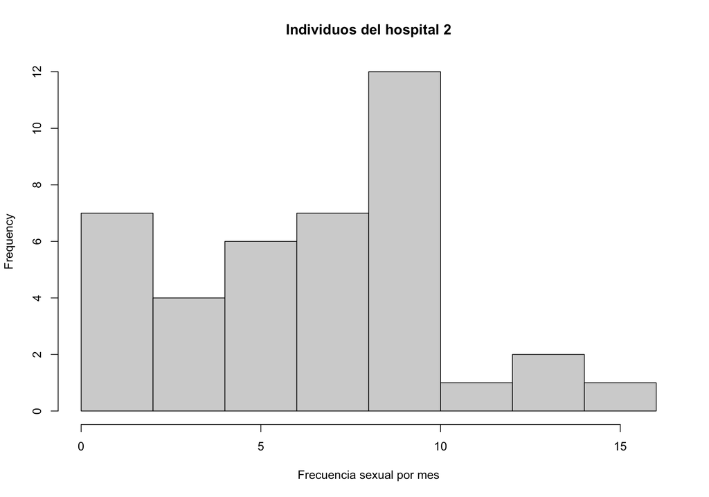

```r
hist(sex_hospital_2,
     breaks = 10,
     main = 'Individuos del hospital 2',
     xlab = 'Frecuencia sexual por mes')
```

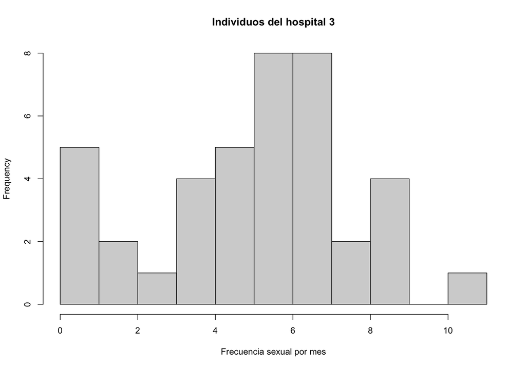

```r
hist(sex_hospital_3,
     breaks = 10,
     main = 'Individuos del hospital 3',
     xlab = 'Frecuencia sexual por mes')
```

```r
data.frame(mean = c(mean(sex_hospital_1), mean(sex_hospital_2), mean(sex_hospital_3)),
           sd = c(sd(sex_hospital_1), sd(sex_hospital_2), sd(sex_hospital_3)),
           numero_observaciones = c(length(sex_hospital_1),
                                    length(sex_hospital_2),
                                    length(sex_hospital_3)),
           row.names = c(factor_hospital_1 , factor_hospital_2, factor_hospital_3))
```

```
##             mean       sd numero_observaciones
## Hospital 1 11.60 3.160656                   40
## Hospital 2  6.90 3.848410                   40
## Hospital 3  5.45 2.650109                   40
```

Las medias y desviaciones estándar son diferentes.

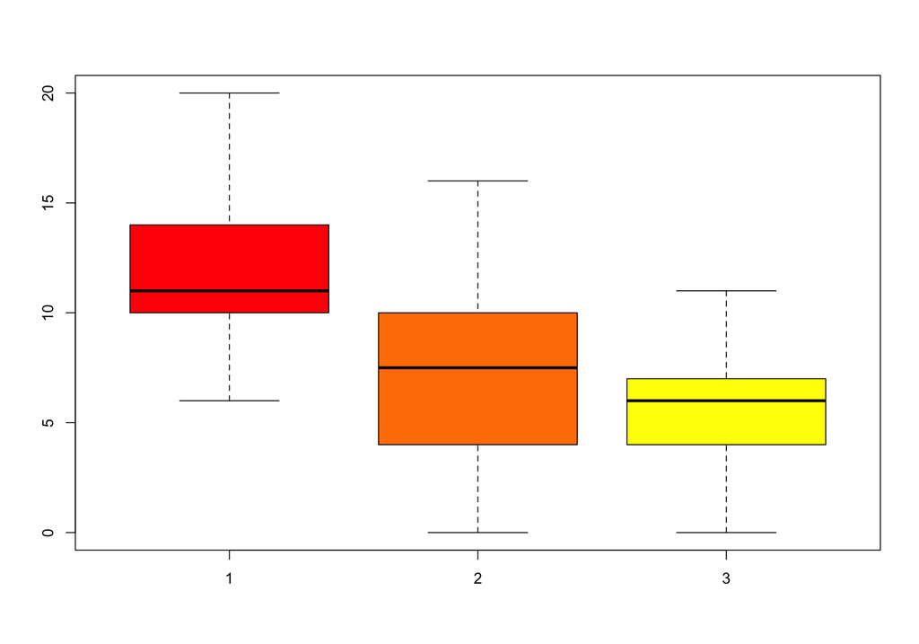

```r
boxplot(sex_hospital_1, sex_hospital_2, sex_hospital_3,
        col = heat.colors(3))
```

### Apartado b

Las hipótesis son:

- H0: Las medias de los tres conjuntos de datos son iguales
- H alternativa: Las medias de los tres conjuntos de datos son diferentes.

```r
sexual_freq_all_hospitals <- c(sex_hospital_1, sex_hospital_2, sex_hospital_3)
hospitals_factor <- as.factor(c(rep(c('Hospital 1', 'Hospital 2', 'Hospital 3'),
                             each = 40)))

anova_hospital <- aov(lm(sexual_freq_all_hospitals ~ hospitals_factor))

summary(anova_hospital)
```

```
##                   Df Sum Sq Mean Sq F value   Pr(>F)
## hospitals_factor   2  826.9   413.4   38.98 1.07e-13 ***
## Residuals        117 1241.1    10.6
## ---
## Signif. codes:  0 '***' 0.001 '**' 0.01 '*' 0.05 '.' 0.1 ' ' 1
```

El valor-p es 1.07e-13 por lo tanto rechazamos H0 y aceptamos la hipótesis alternativa.

Ahora vamos a ver si las muestras son normales. Como n < 50, checkeamos con el test Shapiro-Wilk.

En el test Shapiro-Wilk:

- H0: la distribución de los datos es normal
- H alternativa: la distribución de los datos no es normal.

Si el valor-p es menor de 0.05, rechazaremos H0.

```r
library(stats)

shapiro.test(sex_hospital_1)
```

```
##
##  Shapiro-Wilk normality test
##
## data:  sex_hospital_1
## W = 0.96448, p-value = 0.2375
```

```r
shapiro.test(sex_hospital_2)
```

```
##
##  Shapiro-Wilk normality test
##
## data:  sex_hospital_2
## W = 0.96774, p-value = 0.3045
```

```r
shapiro.test(sex_hospital_3)
```

```
##
##  Shapiro-Wilk normality test
##
## data:  sex_hospital_3
## W = 0.95169, p-value = 0.08673
```

Veamos ahora si es homocedástica (característica de un modelo de regresión lineal que implica que la varianza de los errores es constante a lo largo del tiempo).

Haremos el test de Bartlett para comprobarlo:

- H0: es homocedástica.
- H alternativa: no lo es.

```r
bartlett.test(sexual_freq_all_hospitals ~ hospitals_factor)
```

```
##
##  Bartlett test of homogeneity of variances
##
## data:  sexual_freq_all_hospitals by hospitals_factor
## Bartlett's K-squared = 5.3467, df = 2, p-value = 0.06902
```

El valor-p es 0.069, por lo tanto aceptamos H0 y concluimos que es homocedástica.

### Apartado c

- Valor estadístico de contraste (F): 38.98
- Grados de libertad (Df): 2
- Grados de libertad residuales: 117
- P-value: 1.07e-13

### Apartado d

```r
qf(0.05, 2, 117, lower.tail = FALSE)
```

```
## [1] 3.073763
```

Como el valor F de la ANOVA es 38.98 y es mayor que el valor crítico 3.07, rechazamos la hipótesis nula y concretamos que las medias de las frecuencias sexuales de los tres hospitales son diferentes.

# Sección 3

He hecho una pequeña investigación del paquete Bioconductor

Bioconductor es un proyecto Open Source para el análisis y la comprensión de data genómico en R.

Include una gran variedad de herramientas para importar, limpiar y preprocesar datos genómicos y para guardar y manipular grandes datasets. También incluye herramientas de análisis estadístico para explorar y visualizar datos, incluidas herramientas de análisis de expresión diferencial, análisis de enriquecimiento de conjuntos de genes y agrupación.

Vamos a trabajar con el conjunto de datos de la levadura, que es un hongo microscópico con la capacidad de producir la fermentación (comúnmente la alcohólica) en diversos compuestos orgánicos, como azúcares e hidratos de carbono.

A continuación cargamos el paquete sacCer3, que contiene la información de la levadura de la cerveza: Saccharomyces cerevisiae, usado en la fabricación de pan, cerveza y vino. También veremos el contenido de la variable.

```r
# Asignamos los datos a la variable yeastGenome
yeastGenome <- BSgenome.Scerevisiae.UCSC.sacCer3

# Vemos los head y tails de los nombres de las secuencias y su longitud
head(seqnames(yeastGenome))
```

```
## [1] "chrI"   "chrII"  "chrIII" "chrIV"  "chrV"   "chrVI"
```

```r
tail(seqlengths(yeastGenome))
```

```
##  chrXII chrXIII  chrXIV   chrXV  chrXVI    chrM
## 1078177  924431  784333 1091291  948066   85779
```

A continuación, imprimiremos la secuencia del cromosoma chrXII y su longitud

```r
yeastGenome$chrXII
```

```
## 1078177-letter DNAString object
## seq: CACACACACACACCACCCACACACCACACCACACAC...AACAGGGCTTGGAGGAGACGTACATGAGGGCTATTT
```

```r
nchar(yeastGenome$chrXII)
```

```
## [1] 1078177
```

Veamos la cantidad de Timinas, Adeninas, Citosinas y Guaninas que tiene el gen chrXII

```r
alphabetFrequency(yeastGenome$chrXII, baseOnly = TRUE)
```

```
##      A      C      G      T  other
## 330584 207777 207066 332750      0
```

```r
adn_seq_chrXII <- getSeq(yeastGenome, names = 'chrXII', start = 150, end = 200)
adn_seq_chrXII
```

```
## 51-letter DNAString object
## seq: ATGAAACCCTGTTCTTTAGCCCTACAGCACTTCTACATAGCCCTAAATAGC
```

Transcripción de esa cadena de ADN a ARN

```r
arn_seq_chrXII <- RNAString(adn_seq_chrXII)
arn_seq_chrXII
```

```
## 51-letter RNAString object
## seq: AUGAAACCCUGUUCUUUAGCCCUACAGCACUUCUACAUAGCCCUAAAUAGC
```

Traducción de esa cadena de ARN a aminoácidos

```r
translate(arn_seq_chrXII)
```

```
## 17-letter AAString object
## seq: MKPCSLALQHFYIALNS
```

Mostramos los palíndromos en el genoma del Saccharomyces cerevisiae.

```r
findPalindromes(yeastGenome$chrXII)
```

```
## Views on a 1078177-letter DNAString subject
## subject: CACACACACACACCACCCACACACCACACCACAC...CAGGGCTTGGAGGAGACGTACATGAGGGCTATTT
## views:
##             start     end width
##       [1]     431     439     9 [TATACTATA]
##       [2]     519     526     8 [TAATATTA]
##       [3]     521     529     9 [ATATTATAT]
##       [4]     628     636     9 [TTTGCCAAA]
##       [5]    1040    1048     9 [GCAAGTTGC]
##       ...     ...     ...   ... ...
##   [10014] 1077327 1077335     9 [GCAACTTGC]
##   [10015] 1077739 1077747     9 [TTTGGCAAA]
##   [10016] 1077852 1077860     9 [ATATAATAT]
##   [10017] 1077855 1077862     8 [TAATATTA]
##   [10018] 1077942 1077950     9 [TATAGTATA]
```

Este paquete de R tiene infinidad de funciones dedicadas a la genómica computacional y es algo que seguiré investigando en el futuro.